# Data Feeds

[[edit on GitHub]](https://github.com/chef/automate/blob/master/components/docs-chef-io/content/automate/datafeed.md)

The Data Feed service sends node data to a 3rd party service. This can be useful when updating configuration management databases, external security dashboards, and IT service management platforms. The following types of information are sent:

- Ohai data gathered from each managed node - This data includes hardware, operating system, and installed program information. Some variation depends on the managed operating system.
- Configuration information about each managed node - This information includes Chef Client Run status, Runlists, Cookbooks, and Recipes running against each node.
- Compliance information about each node that shows the compliance state - This information includes passed and failed controls for each profile executed against that node.

A Data Feed operates by doing the following:

- Every 4 hours, the data-feed-service will aggregate the client runs and compliance reports from the previous 4 hours and send this information to the registered destinations. This time interval is 4 hours by default but is configurable.
- If there are no destinations, the aggregation will not occur.
- The data aggregates and sends in batches of 50 nodes at a time. The batch amount is 50 by default but is configurable.

By default, only Admin users of Chef Automate may create and manage Data Feeds.

## Data Feed Integration

Data Feed instance sends client run and compliance scan data to the 3rd party integrations available. To add a Data Feed instance in Chef Automate:

- In the **Settings** tab, navigate to *Data Feeds* in the sidebar
- Select **New Integration**

Currently, the data feed has two types of integrations:

- Webhook Integration
  - ServiceNow
  - Splunk
  - ELK
  - Custom
- Storage Integration
  - Minio
  - Amazon S3

[figure not shown]

## Webhook Integration

Create a data feed using a webhook integration.

### ServiceNow

To create a data feed select **ServiceNow** from **Settings > Data Feed > New Integration**.

1. **Data Feed Name**: A unique name for this notification.
2. **URL**: The endpoint for the data feed integration, including any specific port details.
3. **Authentication**: Select an authentication method.
   1. **Username and Password**
      - **Username**: The name you use to sign in to ServiceNow.
      - **Password**: The password you use to sign in to ServiceNow.
   2. **Access Token**:
      - **Token Type**: The prefix for the authorization used to access ServiceNow endpoints.
      - **Token**: The authorization token value used to access ServiceNow endpoints.
4. Select **Test Connection** to start validating the connection details.
5. Once the test is successful, select **Save** to save the Data Feed configuration.

[figure not shown]

#### Edit a ServiceNow Data Feed Instance

To edit a Data Feed instance of ServiceNow Integration:

1. Select the data feed instance name to open its detail page.
2. Edit the Data Feed **Name** or **URL**.
3. Select the **Test Data Feed** button to test the URL.
4. Select **Save** to save your changes.

[figure not shown]

You can also **Enable/Disable**, and **Delete** the instance from the buttons provided on the details page.

### Splunk

To create a data feed select **Splunk** from **Settings > Data Feed > New Integration**.

1. **Data Feed Name**: A unique name for this notification.
2. **URL**: The endpoint for the data feed integration, including any specific port details.
3. **Authentication**: Select an authentication method.
   1. **Username and Password**
      - **Username**: The name you use to sign in to Splunk.
      - **Password**: The password you use to sign in to Splunk.
   2. **Access Token**:
      - **Token Type**: The prefix for the authorization used to access Splunk endpoints.
      - **Token**: The authorization token value used to access Splunk endpoints.
4. Select **Test Connection** to start validating the connection details.
5. Once the test is successful, select **Save** to save the Data Feed configuration.

[figure not shown]

#### Edit a Splunk Data Feed Instance

To edit a Data Feed instance of Splunk Integration:

1. Select the data feed instance name to open its detail page.
2. Edit the Data Feed **Name** or **URL**.
3. Select the **Test Data Feed** button to test the URL.
4. Select **Save** to save your changes.

[figure not shown]

You can also **Enable/Disable**, and **Delete** the instance from the buttons provided on the details page.

### ELK

To create a data feed select **ELK** from **Settings > Data Feed > New Integration**.

1. **Data Feed Name**: A unique name for this notification.
2. **URL**: The endpoint for the data feed integration, including any specific port details.
3. **Authentication**: Select an authentication method.
   1. **Username and Password**
      - **Username**: The name you use to sign in to ELK.
      - **Password**: The password you use to sign in to ELK.
   2. **Access Token**:
      - **Token Type**: The prefix for the authorization used to access ELK endpoints.
      - **Token**: The authorization token value used to access ELK endpoints.
4. Select **Test Connection** to start validating the connection details.
5. Once the test is successful, select **Save** to save the Data Feed configuration.

[figure not shown]

#### Edit an ELK Data Feed Instance

To edit a Data Feed instance of ELK Integration:

1. Select the data feed instance name to open its detail page.
2. Edit the Data Feed **Name** or **URL**.
3. Select the **Test Data Feed** button to test the URL.
4. Select **Save** to save your changes.

[figure not shown]

You can also **Enable/Disable**, and **Delete** the instance from the buttons provided on the details page.

### Custom

To create a data feed select **Custom** from **Settings > Data Feed > New Integration**.

1. **Data Feed Name**: A unique name for this notification.
2. **URL**: The endpoint for the data feed integration, including any specific port details.
3. **Authentication**: Select an authentication method.
   1. **Username and Password**
      - **Username**: The name you use to sign in to Custom Integration.
      - **Password**: The password you use to sign in to Custom Integration.
   2. **Access Token**:
      - **Token Type**: The prefix for the authorization used to access Custom Integration endpoints.
      - **Token**: The authorization token value used to access Custom Integration endpoints.
4. Select **Use Headers** checkbox to add custom headers (For example: `key:value`).
5. Select **Test Connection** to start validating the connection details.
6. Once the test is successful, select **Save** to save the Data Feed configuration.

[figure not shown]

#### Edit a Custom Data Feed Instance

To edit a Data Feed instance of Custom Integration:

1. Select the data feed instance name to open its detail page.
2. Edit the Data Feed **Name** or **URL**.
3. Select the **Test Data Feed** button to test the URL.
4. Select **Save** to save your changes.

[figure not shown]

You can also **Enable/Disable**, and **Delete** the instance from the buttons provided on the details page.

## Storage Integration

Create a data feed using a storage integration.

### Minio

To create a data feed select **Minio** from **Settings > Data Feed > New Integration**.

1. **Data Feed Name**: A unique name for this notification.
2. **Endpoint**: The endpoint for the data feed integration, including any specific port details.
3. Enter a **Bucket Name**, **Access Key**, and the **Secret Key** of the instance.
4. Select **Test Connection** to start validating the connection details.
5. Once the test is successful, select **Save** to save the Data Feed configuration.

[figure not shown]

#### Edit a Minio Data Feed Instance

To edit a Data Feed instance of Minio Integration:

1. Select the data feed instance name to open its detail page.
2. Edit the Data Feed **Name**, **End Point**, or the **Bucket**.
3. Select the **Test Data Feed** button to test the Endpoint.
4. Select **Save** to save your changes.

[figure not shown]

You can also **Enable/Disable**, and **Delete** the instance from the buttons provided on the details page.

### Amazon S3

To create a data feed select **S3** from **Settings > Data Feed > New Integration**.

[figure not shown]

#### Edit an S3 Data Feed Instance

To edit a Data Feed instance of S3 Integration:

1. Select the data feed instance name to open its detail page.
2. Edit the Data Feed **Name**, **Region** or the **Bucket**.
3. Select the **Test Data Feed** button to test the Endpoint.
4. Select **Save** to save your changes.

[figure not shown]

You can also **Enable/Disable**, and **Delete** the instance from the buttons provided on the details page.

## Enable/Disable a Data Feed Instance

Chef Automate lets you temporarily disable the data feed. It can be helpful if the data feed is going under maintenance or you don’t want to send the node or compliance data to a data feed.

The data feed instances are by default enabled when created. To disable a feed:

[figure not shown]

To enable a disabled data feed:

[figure not shown]

## Delete a Data Feed Instance

To delete an individual instance:

[figure not shown]

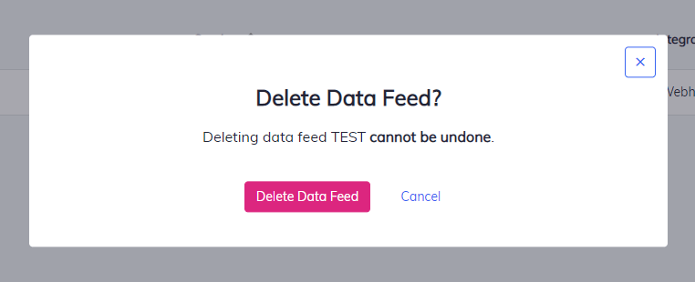

## Configuring Global Data Feed Behavior

Note

The Data Feed configuration settings apply across all configured Data Feed instances.

To modify Data Feed behavior with the available configuration settings:

- Create a configuration patch file to update the configuration settings. Save this file in the `.toml` file format and name your file as desired. For example, `data-feed-patch.toml`
- Include one or more configuration settings and their updated value(s) in your configuration patch `.toml` file to reflect the desired global Data Feed behavior:
  - Use the `feed_interval` setting to change the interval for the Data Feed collection. The default value is four hours
  - Use the `node_batch_size` setting to change the number of sets of node data sent in each batch to your endpoint. The default value is 50 nodes
  - Use the `updated_nodes_only` setting to determine what data to include in each export. The default setting is `true`, which causes the aggregation of only the *changed* data of updated nodes since the last export. Set `updated_nodes_only` to `false`, and it aggregates *all* data of updated nodes since the last export
  - To reduce the IP address range for the collected and processed node data, update the `disable_cidr_filter` setting to `false` **and** update the `cidr_filter` setting to cover the required IP address range. For example, you may wish to send only production or test node traffic
  - Use the `accepted_status_codes` setting to define an array of HTTP status codes that the Data Feed Service will treat as `success` if returned by the 3rd party endpoint. If the status code is not in the `accepted_status_codes` list, then an error will be logged
- Save your configuration patch file changes before continuing to the next step.
- Apply your configuration changes with the Chef Automate command-line tool:

```bash
    chef-automate config patch data-feed-patch.toml
```

```
where `data-feed-patch.toml` is this example's configuration patch file.
```

### Configuration Patch File Example

```
[data_feed_service.v1.sys]
  [data_feed_service.v1.sys.service]
        feed_interval = "4h"
        node_batch_size = 50
        updated_nodes_only = true
        disable_cidr_filter = true
        cidr_filter = "0.0.0.0/0"
        accepted_status_codes = [200, 201, 202, 203, 204]
      [data_feed_service.v1.sys.log]
        level = "info"
```

```
    [data_feed_service.v1.sys.log]
    log_level = "debug"
```

## Data Feed Output Syntax and Details

The outputted data from Data Feed consists of line-separated JSON strings. Each line represents the data for one node and contains the following properties:

```json
    {
    "attributes": {
     "node_id": "",
     "name": "",
     "run_list": [],
     "chef_environment": "",
     "normal": {},
     "default": {},
     "override":{},
     "automatic":{},
     "normal_value_count": 0,
     "default_value_count": 1,
     "override_value_count": 1,
     "all_value_count": 10,
     "automatic_value_count": 8
    },
    "report": { ... },
    "client_run": { ... },
    "node": {
     "automate_fqdn": "",
     "ip_address" : "",
     "mac_address": "",
     "description":"",
     "serial_number":"",
     "os_service_pack":""
     }
    }
```